# Data Science Capstone

Shun-Wen Chang

September 25, 2016

This is the milestone report for Data Science Capstone project from Coursera Data Science Specialization. The objectives of this report is to load the 3 given data sets, summarize the data, and explore the data to understand the frequency distribution of words and 2-gram, 3-gram words.

### 0. Examine Data

Before loading data, let’s check the data size and word counts within bash shell.

**check file sizes**  
-rw-r–r–@ 1 EstherChang staff 167105338 Jul 22 2014 en_US.twitter.txt  
-rw-r–r–@ 1 EstherChang staff 205811889 Jul 22 2014 en_US.news.txt  
-rw-r–r–@ 1 EstherChang staff 210160014 Jul 22 2014 en_US.blogs.txt

**check line counts**  
899288 en_US.blogs.txt  
1010242 en_US.news.txt  
2360148 en_US.twitter.txt  
4269678 total

### 1. Load Data and necessary packages

```r
setwd("/Users/EstherChang/Documents/R/Data_Science_captone/final/en_US/")
blog <- readLines("en_US.blogs.txt",skipNul = TRUE, warn = TRUE)
news <- readLines("en_US.news.txt",skipNul = TRUE, warn = TRUE)
twitter <- readLines("en_US.twitter.txt",skipNul = TRUE, warn = TRUE)

library(ggplot2)
library(NLP)
library(tm)
library(RWeka)
```

### 2. Data Sampling

Because these data are huge. We need to make a sample subset to do this project. In each file, I select random 1000 entries as my data source and then delete the original data to release memory space.

```r
set.seed(100)
sample_size = 1000

sample_blog <- blog[sample(1:length(blog),sample_size)]
sample_news <- news[sample(1:length(news),sample_size)]
sample_twitter <- twitter[sample(1:length(twitter),sample_size)]
```

**Examing the first few lines of each data set:**

```r
head(sample_blog)
```

```
## [1] "So. Jeff has a talk with the monkey and tries to explain to him that he needed to have courage to eat the zucchini. He needed to look at it like Super Man would look at kryptonite and ATTACK the zucchini! The boy took a couple of quick breaths and ran back into the kitchen, determined to bea…
## [2] "or feel free to email me at"
## [3] "Part 1: My Very First Competition"
## [4] "4.Tribute My Ass"
## [5] "Something Shiny Syndrome."
## [6] "Stop mumbling. (any suggestions from my speech-pathologist pals?) Yeah, didn't do so well with this one. Maybe I need some therapy or shock treatments."
```

```r
head(sample_twitter)
```

```
## [1] "because Scott Walker is a lying ASS"
## [2] "Banana Republic didn't have what I wanted, so I tried God-Forsaken Hellhole."
## [3] "LGBT Civil Rights March/Rally DC. Check facebook messages. Thx Wanda! Woot!"
## [4] "hey where's you get your face? The toilet store?"
## [5] "Regardless of the final score, this team has proven their worth. I'm crying. What a game!!!"
## [6] "Dylan, Nathan, ean, & Anthony comin over. :)"
```

```r
head(sample_news)
```

```
## [1] "Too bad, in this case at least, that we don't say the word, because it might force us to face a foul and unacceptable human-rights inequality."
## [2] "DOLORES JOAN WHIPPLE, 76, DeLand, died Sunday. Newcomer Funeral Home, Orlando."
## [3] "J&J shares fell 36 cents, or less than 1 percent, Friday to $62.55 in New York Stock Exchange composite trading. The company's shares have declined 3.9 percent in the last 12 months."
## [4] "Delayed opening a new state hospital in Junction City, saving $19.6 million"
## [5] "Since his term as California governor ended in early January, Schwarzenegger, 63, has hopscotched around the world, his wife nowhere in sight. While the \"Terminator\" star appeared confident about the future since exiting politics, cutting movie deals and fashioning himself as a global spok…
## [6] "\"We now have the opportunity to create a world-class theme park destination that will allow guests from around the globe to experience Six Flags' unique combination of thrills and entertainment.\""
```

**Then combine all 3 data and remove originals:**

```r
sample_data<-rbind(sample_blog,sample_news,sample_twitter)
rm(blog,news,twitter)
```

### 3. Clean Data

**I clean the data with following rules:** 1. remove punctuation 2. remove whitespace 3. discard numbers since they are irrelavant in our analysis 4. convert to all lowercases

**Clean the data using tm_map:**

```r
mycorpus<-VCorpus(VectorSource(sample_data))
mycorpus <- tm_map(mycorpus, content_transformer(tolower)) # convert to lowercase
mycorpus <- tm_map(mycorpus, removePunctuation) # remove punctuation
mycorpus <- tm_map(mycorpus, removeNumbers) # remove numbers
mycorpus <- tm_map(mycorpus, stripWhitespace) # remove multiple whitespace
changetospace <- content_transformer(function(x, pattern) gsub(pattern, " ", x))
mycorpus <- tm_map(mycorpus, changetospace, "/|@|\\|")
```

### 4. Tokenize the sentences

We use NGramTokenizer in RWeka package for this task. In this project, we analyze 1gram, 2gram, and 3gram, which I will call “oneGM”, “twoGM”, and “threeGM”, respectively for the n-gram matrices.

```r
uniGramTokenizer <- function(x) NGramTokenizer(x, Weka_control(min = 1, max = 1))
biGramTokenizer <- function(x) NGramTokenizer(x, Weka_control(min = 2, max = 2))
triGramTokenizer <- function(x) NGramTokenizer(x, Weka_control(min = 3, max = 3))
OneT <- NGramTokenizer(mycorpus, Weka_control(min = 1, max = 1))
oneGM <- TermDocumentMatrix(mycorpus, control = list(tokenize = uniGramTokenizer))
twoGM <- TermDocumentMatrix(mycorpus, control = list(tokenize = biGramTokenizer))
threeGM <- TermDocumentMatrix(mycorpus, control = list(tokenize = triGramTokenizer))
```

### 5. Generate n-gram histograms

**Unigram frequency**

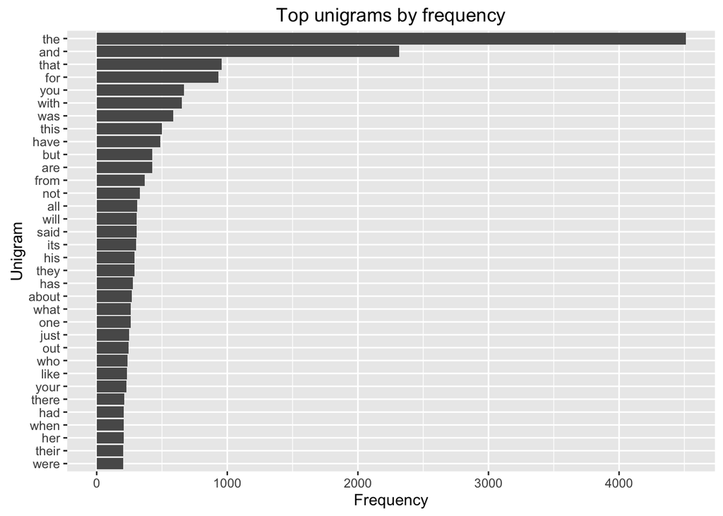

```r
freqTerms <- findFreqTerms(oneGM, lowfreq = 200)
termFreq <- rowSums(as.matrix(oneGM[freqTerms,]))
termFreq <- data.frame(unigram=names(termFreq), frequency=termFreq)

g1 <- ggplot(termFreq, aes(x=reorder(unigram, frequency), y=frequency)) +
    geom_bar(stat = "identity") +  coord_flip() +
    theme(legend.title=element_blank()) +
    xlab("Unigram") + ylab("Frequency") +
    labs(title = "Top unigrams by frequency")
print(g1)
```

**Bigram frequency**

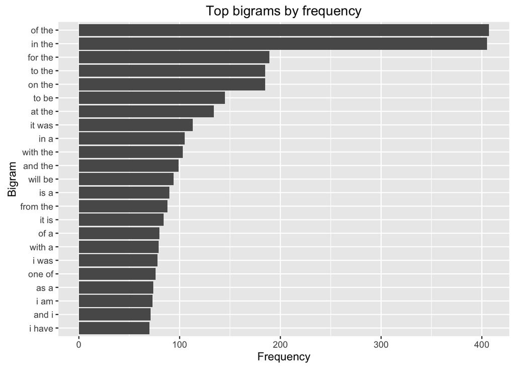

```r
freqTerms <- findFreqTerms(twoGM, lowfreq = 70)
termFreq <- rowSums(as.matrix(twoGM[freqTerms,]))
termFreq <- data.frame(bigram=names(termFreq), frequency=termFreq)

g2 <- ggplot(termFreq, aes(x=reorder(bigram, frequency), y=frequency)) +
    geom_bar(stat = "identity") +  coord_flip() +
    theme(legend.title=element_blank()) +
    xlab("Bigram") + ylab("Frequency") +
    labs(title = "Top bigrams by frequency")
print(g2)
```

**Trigram frequency**

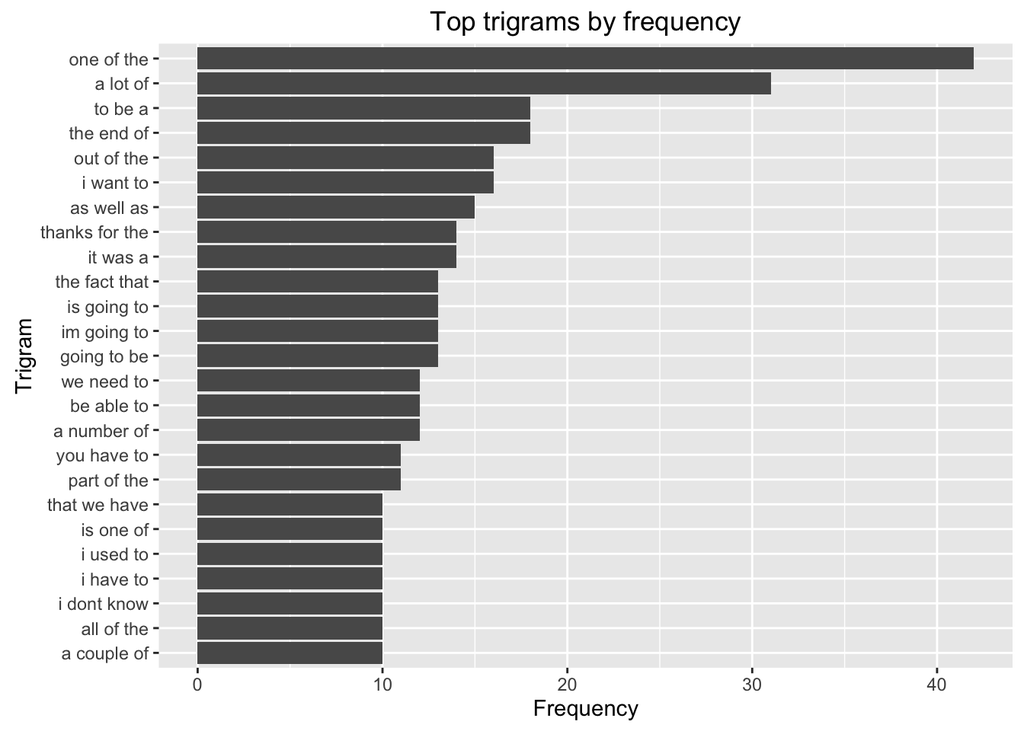

```r
freqTerms <- findFreqTerms(threeGM, lowfreq = 10)
termFreq <- rowSums(as.matrix(threeGM[freqTerms,]))
termFreq <- data.frame(trigram=names(termFreq), frequency=termFreq)

g3 <- ggplot(termFreq, aes(x=reorder(trigram, frequency), y=frequency)) +
    geom_bar(stat = "identity") +  coord_flip() +
    theme(legend.title=element_blank()) +
    xlab("Trigram") + ylab("Frequency") +
    labs(title = "Top trigrams by frequency")
print(g3)
```